# Data_Analysis_Project

## [Resume Link](https://JStubbsUVU.github.io/Media/Josh_Stubbs_Resume.pdf) | Final Project

## **Electric Vehicles**

**Joshua Stubbs final project analysis of electric vehicles**

## **Introduction**

**The goal of this project is to analyze and obtain a better understanding of electric vehicles. There are many concerns and questions asked about electric vehicles like what their range is or what the cost to charge them is. The data set for this project was found on an electric vehicle form where people can collectively update and add information about existing and new electric vehicles.**

## **Date and Range**

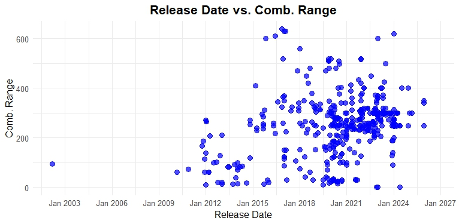

**This plot shows the release date and the combine range. It helps to show that electric vehicles range have increased overtime. It also shows that there were not many electric vehicles being produced prior to 2015.**

## **Battery Kilowatt & Range**

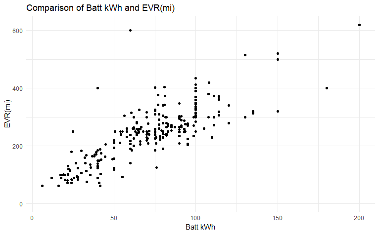

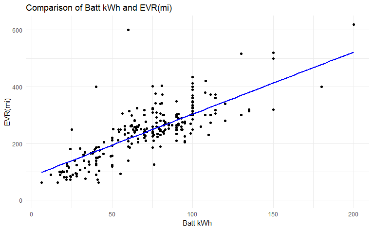

**These two plots both show a comparison of battery kilowatt and the electric vehicle range in miles. These help show a trend of increasing range with the kilowatt density of batteries. It can also be observed that it is currently hard to obtain a range of over 400 miles. This is likely due to battery weight and the current power output per kilowatt.**

## **Model Plot**

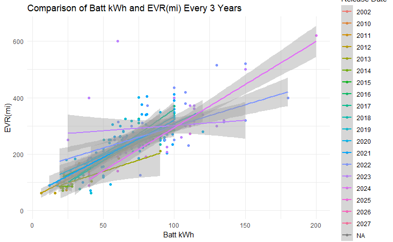

## **Model Table**

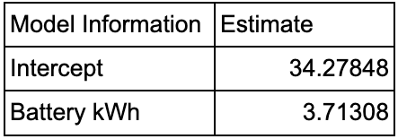

## **Calculations**

[figure not shown]

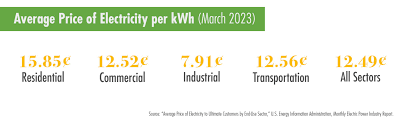

**This is the formula to calculate the cost to charge an electric vehicle. With the average cost per kilowatt, it is simple to use the prior formula and calculate cost to charge. Multiplying the battery kilowatt to the average cost per kilowatt gives you cost to charge. For example a long range Tesla Model 3 has a 75 kWh battery capacity. With the provided formula, the cost to charge would be 11.88.**

## **Fun Facts**

[figure not shown]

*This is the pre production Jaguar I-pace that will first be launched in Europe.*

[figure not shown]

The current longest range vehicle in the United States is the Lucid Air. On a fast charger, it will charge to 200 miles in 12 minutes. This vehicle has a trim that has a max power of 1,234 hp and a 0-60 time of 1.89 seconds. The longest range option is currently 115,600 dollars.